# Session 3 Uncertainty visualizations

Xiaoying Pu, Lace Padilla

3/3/2022

## Introduction

We will revisit Datasets 1 from last time, focusing on exploring how to make **visualizations** instead of doing the analysis. By the end of this tutorial, you will learn to:

1. Apply the **Grammar of Graphics** to build simple plots
2. Identify the types of **uncertainty** from model outputs and modify code to visualize model outputs and uncertainty
3. Use resources to find options for making a plot more **expressive** and evaluate its **usability**

### Expectations

I will mainly be coding here during this tutorial. You have the same skeleton code in your Rstudio Cloud. Ideally, you will follow along and write code with me. There are many activities where you can **participate** and ask **questions** (any time!). We will gradually transition from me providing examples to you creating your own plots.

Two files:

- `session-3-vis.Rmd` (this document we’re working on)
- `session-3-vis-ref.Rmd` (the “answer key” document, with the exercises filled in)

### Pre-survey

What makes a plot? How do you systematically describe a plot, like linguists using **grammar** to describe a language?

**Poll** (reply in Zoom chat)

- Have you used ggplot before?
  $$Y/N$$
- How familiar are you with “Grammar of Graphics”?
  $$1..5$$
  - 1: Haven’t heard of it
  - 5: Very familiar, know how it relates to ggplot

It’s OK if you don’t know everything yet! It’s all part of the plan 🤔

(Review survey response)

## Activity 1: exploring data

First, we will learn the “grammar” behind ggplot. By the end of this activity, you will be able to read and write basic ggplot specifications and understand what you’re doing. Also, you need to explore and understand the raw data before doing analysis anyways.

### Load the data

We will base our example on the `blinded.csv` dataset. It’s from an experiment about whether showing people graphs increase belief in drug efficacy, presumably because graphs are associated with science.

**TIP**: `()` enclosing an assignment will print the assigned value as well.

```r
(df1 <- read_csv("data/blinded.csv", show_col_types = FALSE) %>%
  filter(experiment == 1) %>%
  mutate(
    condition = factor(condition),
    participant_id = paste0("P", str_pad(row_number(), 2, pad = "0"))) %>%
   select(-experiment)
)
```

```
## # A tibble: 123 × 3
##    condition effectiveness participant_id
##    <fct>             <dbl> <chr>
##  1 no_graph              7 P01
##  2 graph                 6 P02
##  3 no_graph              9 P03
##  4 no_graph              4 P04
##  5 graph                 6 P05
##  6 no_graph              7 P06
##  7 graph                 7 P07
##  8 no_graph              7 P08
##  9 no_graph              7 P09
## 10 graph                 6 P10
## # … with 113 more rows
```

### Explore the data with ggplot

Last time, we modeled how `condition` (graph or no graph) affected `effectiveness`, a Likert scale rating from 1 to 9.

To start out, we will create a scatterplot of effectiveness vs. condition. Your plot will end up like this

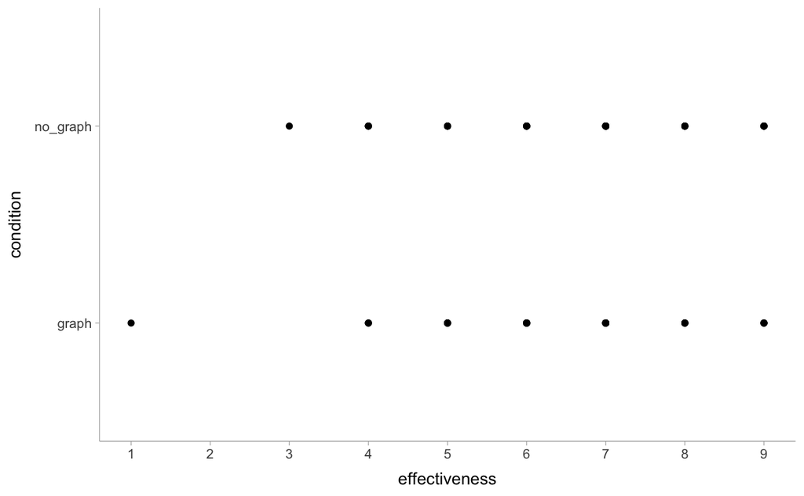

The ggplot specification is the following:

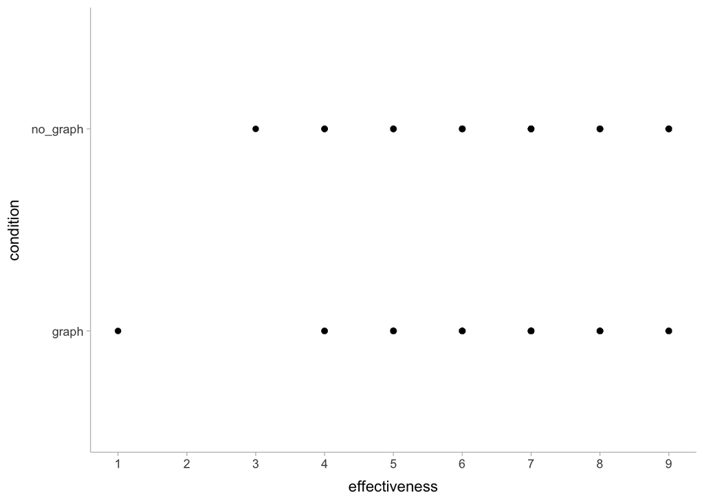

```r
df1 %>%
  ggplot(aes(
    x = effectiveness,
    y = condition)) +
  geom_point() +
  scale_x_continuous(breaks = 1:9)
```

Let’s break it down in terms of the (layered) Grammar of Graphics concepts so that we can understand how ggplot works:

**Notability doodling**

- `ggplot`: creates the “default layer”
- `geom_point()`: Mark/geometry of type point, also a layer
- `aes`: Aesthetics, aka visual channel encoding. If `aes()` is within `ggplot`, the mappings apply to all layers, unless other layers override them.

  ```
  x <- effectiveness
  y <- condition
  ```

**REFLECTION**: is this plot good? Is it showing all the data points? (Think *expressiveness*)

**Solution**:

```r
jitterer <- position_jitter(height = 0.1, seed = 1)
```

Let’s write the Grammar of Graphics spec and add more “color” to it (color the points by `condition` variable)

**PREDICT**: how should the new spec look like?

```
ggplot
    x <- effectiveness
    y <- condition
geom_point
```

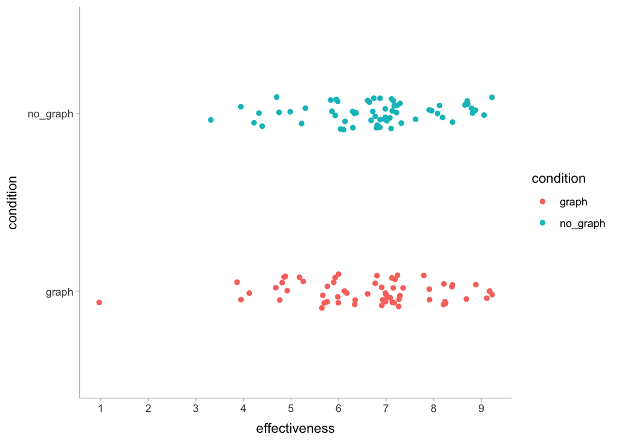

```r
df1 %>%
  ggplot(aes(
    x = effectiveness,
    y = condition,
    # EXERCISE: add color
    color = condition
  )) +
  # EXERCISE: make points jitter
  geom_point(position = jitterer) +
  scale_x_continuous(breaks = 1:9)
```

**Reflection**: is this a better representation? Do you have a better idea?

**Preview**: intrinsic uncertainty in the data (sans the artificial jitter!)

**TIP**: Common problem and how to fix:

```r
df1 %>%
  ggplot() +
  geom_point(
    x = effectiveness,
    y = condition,
    color = condition,
    position = jitterer)
```

**RELFECTION:** any questions about Grammar of Graphics/ggplot syntax so far?

## Activity 2: t-test/simple linear regression

The two tables are a roadmap of what we’re going to do: mapping uncertainty onto different representations

1. Understand types of uncertainty

| Uncertainty type | From data/model outputs |
| --- | --- |
| (Intrinsic) | ? |
| Parameter | ? |
| Prediction | ? |

2. Know how to show (the different types of) uncertainty. **PREDICTION**: which representation is most *expressive*?

| Uncertainty representation | Frequentist | Bayesian |
| --- | --- | --- |
| Table summary | TODO |  |
| Point estimate |  |  |
| Interval |  |  |
| Distribution |  |  |

### Load Frequentist and Bayesian models

t-test is equivalent to a linear model estimating two means. For the frequentist version, we are using `lm` because the output is easier to wrangle (good explainer: https://lindeloev.github.io/tests-as-linear/#61_one-way_anova_and_kruskal-wallis)

```r
(m_t_test <- lm(effectiveness ~ - 1 + condition, data = df1))
```

```
##
## Call:
## lm(formula = effectiveness ~ -1 + condition, data = df1)
##
## Coefficients:
##    conditiongraph  conditionno_graph
##             6.574              6.758
```

The Bayesian t-test:

```r
(m_t_test_bayesian <- readRDS("../02-bayesian_stats/rds/dataset1.brm.bayesiant.rds"))
```

```
##  Family: student
##   Links: mu = identity; sigma = identity; nu = identity
## Formula: effectiveness ~ condition - 1
##    Data: exp1.data (Number of observations: 123)
##   Draws: 4 chains, each with iter = 2000; warmup = 1000; thin = 1;
##          total post-warmup draws = 4000
##
## Population-Level Effects:
##                   Estimate Est.Error l-95% CI u-95% CI Rhat Bulk_ESS Tail_ESS
## conditiongraph        6.61      0.18     6.25     6.96 1.00     3840     2692
## conditionno_graph     6.77      0.17     6.43     7.11 1.00     3211     2355
##
## Family Specific Parameters:
##       Estimate Est.Error l-95% CI u-95% CI Rhat Bulk_ESS Tail_ESS
## sigma     1.30      0.11     1.07     1.52 1.00     3172     2490
## nu       16.84     11.62     4.36    46.74 1.00     3081     2832
##
## Draws were sampled using sampling(NUTS). For each parameter, Bulk_ESS
## and Tail_ESS are effective sample size measures, and Rhat is the potential
## scale reduction factor on split chains (at convergence, Rhat = 1).
```

### Build dataframes for table views

**Table** is the most basic way of reporting the results.

Tables for confidence/credible interval (CI), or **parameter uncertainty:**

For the **frequentist** analysis:

```r
(means_t_freq <- m_t_test %>%
   tidy() %>%
   mutate(condition = str_remove(term, "condition"), .before = 1) %>%
   select(-term)
)
```

```
## # A tibble: 2 × 5
##   condition estimate std.error statistic  p.value
##   <chr>        <dbl>     <dbl>     <dbl>    <dbl>
## 1 graph         6.57     0.183      36.0 1.76e-66
## 2 no_graph      6.76     0.181      37.3 3.31e-68
```

How to interpret this table:

- `estimate` column is for the estimates of the conditional means
- `std.error` is the standard error for each mean, and we can get confidence intervals (CI) from it later
  - Math: $\sqrt{MSE \left(\frac{1}{n} + \frac{(x_h - \bar{x})^2}{\sum{(x_i - \bar{x})^2}}\right)}$
  - **REFLECTION**: what kind of uncertainty is this?
- `statistic` is the value of a T-statistic
- 95% CI ($\alpha = 0.05$) is $t_{1 - 0.05/2, df} \times \sqrt{MSE \left(\frac{1}{n} + \frac{(x_h - \bar{x})^2}{\sum{(x_i - \bar{x})^2}}\right)}$, where the t-multiplier $t_{1 - 0.05/2, df}$ is calculated as `qt(1 - 0.05/2, df)`.

For the **Bayesian model**, we get draws from the posterior predictive *expectations* (means) of all the parameters of the t-distribution ($\mu$/`.epred`, $\sigma$, $\nu$). There is credible interval (CI) for Bayesian models, but we’re not summarizing intervals yet.

```r
(means_t_bayes <- data_grid(df1, condition) %>%
  add_epred_draws(m_t_test_bayesian, newdata = . ,dpar = TRUE))
```

```
## # A tibble: 8,000 × 9
## # Groups:   condition, .row [2]
##    condition  .row .chain .iteration .draw .epred    mu sigma    nu
##    <fct>     <int>  <int>      <int> <int>  <dbl> <dbl> <dbl> <dbl>
##  1 graph         1     NA         NA     1   6.48  6.48  1.41 26.7
##  2 graph         1     NA         NA     2   6.75  6.75  1.13  5.63
##  3 graph         1     NA         NA     3   6.59  6.59  1.25  9.63
##  4 graph         1     NA         NA     4   6.55  6.55  1.41 25.9
##  5 graph         1     NA         NA     5   6.53  6.53  1.27 15.3
##  6 graph         1     NA         NA     6   6.53  6.53  1.23 14.7
##  7 graph         1     NA         NA     7   6.49  6.49  1.28 22.3
##  8 graph         1     NA         NA     8   6.51  6.51  1.30  7.73
##  9 graph         1     NA         NA     9   6.84  6.84  1.35 10.3
## 10 graph         1     NA         NA    10   6.80  6.80  1.26 10.7
## # … with 7,990 more rows
```

From a bunch of samples to a summary table:

```r
means_t_bayes %>%
  median_qi(.epred, .width = c(0.95))
```

```
## # A tibble: 2 × 8
##   condition  .row .epred .lower .upper .width .point .interval
##   <fct>     <int>  <dbl>  <dbl>  <dbl>  <dbl> <chr>  <chr>
## 1 graph         1   6.60   6.25   6.96   0.95 median qi
## 2 no_graph      2   6.77   6.43   7.11   0.95 median qi
```

**Prediction interval (PI), and prediction uncertainty**

**DISCUSSION**: Prediction uncertainty? Compared to parameter uncertainty? What are they for? Which is wider and why?

For the **frequentist** model. `.fitted` is the same as the `estimate` above. `.se.pred` times the t-multiplier is the PI. $t_{1 - 0.05/2, df} \times \sqrt{MSE \left(1 + \frac{1}{n} + \frac{(x_h - \bar{x})^2}{\sum{(x_i - \bar{x})^2}}\right)}$

Notes on calculating the `se.pred`: https://online.stat.psu.edu/stat501/lesson/3/3.3 gives a good explanation, and to translate the mathematical notation to R code:

- MSE is `sum(residuals(m_t_test))/df.residual(m_t_test)`
- Variance due to estimating the mean `.se.fit^2`
- Variance due to variation in the response variable `residual.scale^2`
- The standard error of prediction is the square root of the two variances combined

```r
# predict() returns $residual.scale
preds_t_freq_obj <- predict(m_t_test, newdata = data_grid(df1, condition),
                     se.fit=TRUE, interval = "prediction", level = 0.95)

(preds_t_freq <- m_t_test %>%
  augment(newdata = data_grid(df1, condition), se_fit = TRUE) %>%
  mutate(
    .se.pred = sqrt(.se.fit ^ 2 + preds_t_freq_obj$residual.scale^2), # NOTE
    df = preds_t_freq_obj$df
  )
)
```

```
## # A tibble: 2 × 5
##   condition .fitted .se.fit .se.pred    df
##   <fct>       <dbl>   <dbl>    <dbl> <int>
## 1 graph        6.57   0.183     1.44   121
## 2 no_graph     6.76   0.181     1.44   121
```

Predictions for the **Bayesian** model: get draws from the posterior predictive distribution (different from `epred` from above!)

```r
(preds_t_bayes <- data_grid(df1, condition) %>%
    add_predicted_draws(m_t_test_bayesian))
```

```
## # A tibble: 8,000 × 6
## # Groups:   condition, .row [2]
##    condition  .row .chain .iteration .draw .prediction
##    <fct>     <int>  <int>      <int> <int>       <dbl>
##  1 graph         1     NA         NA     1        2.62
##  2 graph         1     NA         NA     2        7.83
##  3 graph         1     NA         NA     3        7.27
##  4 graph         1     NA         NA     4        8.50
##  5 graph         1     NA         NA     5        5.21
##  6 graph         1     NA         NA     6        5.18
##  7 graph         1     NA         NA     7        6.33
##  8 graph         1     NA         NA     8        8.62
##  9 graph         1     NA         NA     9        5.95
## 10 graph         1     NA         NA    10        7.01
## # … with 7,990 more rows
```

```r
preds_t_bayes %>%
  median_qi(.width = 0.95)
```

```
## # A tibble: 2 × 8
##   condition  .row .prediction .lower .upper .width .point .interval
##   <fct>     <int>       <dbl>  <dbl>  <dbl>  <dbl> <chr>  <chr>
## 1 graph         1        6.60   3.74   9.51   0.95 median qi
## 2 no_graph      2        6.74   3.93   9.64   0.95 median qi
```

### Point estimates of the mean

**Frequentist** `lm()` model, plot estimates of the mean effectiveness by condition:

**EXERCISE**: First, use pseudo Grammar of Graphics/ggplot to articulate what you want. Remember the scatterplot we made earlier?

```
geom_point
  x <- estimate
  y <- condition
```

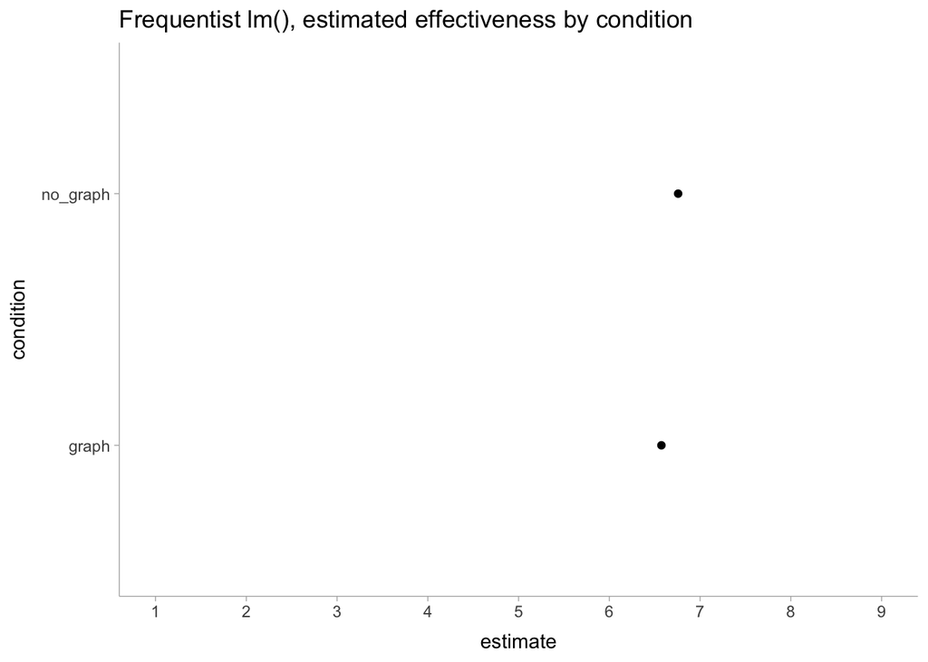

```r
means_t_freq %>%
  ggplot(aes(x = estimate, y = condition)) +
  geom_point() +
  scale_x_continuous(breaks = 1:9, limits = c(1, 9)) +
  labs(title = "Frequentist lm(), estimated effectiveness by condition") +
  NULL
```

**Bayesian** and frequentist combined, because why not?

```
geom_point
  x <- estimate
  y <- condition
  color <- model????
```

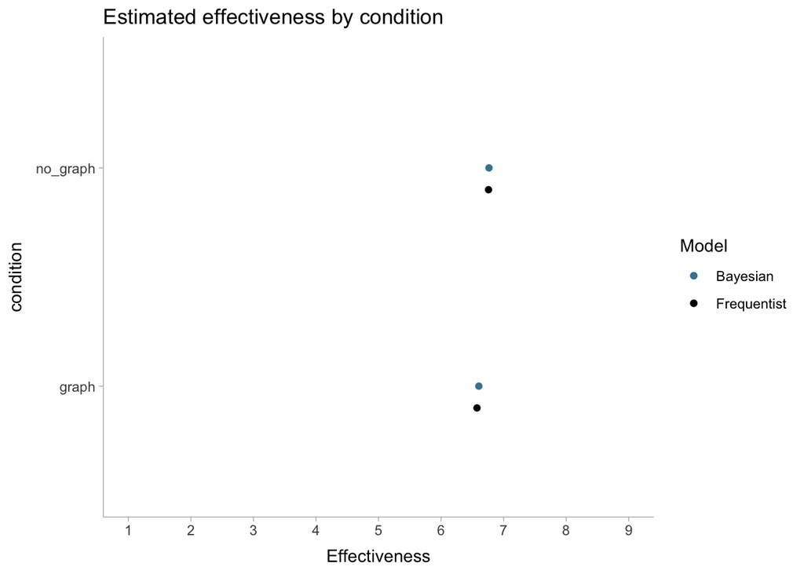

```r
# EXERCISE: add the frequentist point estimates to the plot
(p_pt_est <- means_t_bayes %>%
  median_qi(.epred, .width = c(0.95)) %>%
  ggplot(aes(x = .epred, y = condition)) +
  geom_point(aes(color = "Bayesian")) +
  geom_point(
    aes(x = estimate,
    color = "Frequentist"),
    data = means_t_freq,
    position = position_nudge(y = -0.1)) +
  scale_x_continuous("Effectiveness", breaks = 1:9, limits = c(1, 9)) +
  scale_color_manual("Model",
                     breaks = c("Bayesian", "Frequentist"),
                     values  = c("#45829f", "#000000") ) +
  labs(title = "Estimated effectiveness by condition") +
  NULL
)
```

```r
# REFLECTION: what just happened? How is that legend generated?
# TOOL! https://yjunechoe.github.io/posts/2022-03-10-ggplot2-delayed-aes-1/
# layer_data(p_pt_est, i = 1)
```

**REFLECTION**: How good is this model comparison?

**REFLECTION**: Any questions plotting points?

### Intervals - parameter and prediction uncertainty

Add interval for uncertainty. For the **frequentist** model, the *confidence distribution* for the parameters follows the student-t distribution. https://mjskay.github.io/ggdist/articles/freq-uncertainty-vis.html

To specify a studdent-t distribution, we need three parameters:

- df: degree of freedom (N-2)
- mu: estimate/.fitted for the mean … `estimate` column is for the estimates of the group means
- sigma: standard error … `std.error` is the standard error. Math: $\sqrt{MSE \left(\frac{1}{n} + \frac{(x_h - \bar{x})^2}{\sum{(x_i - \bar{x})^2}}\right)}$

We won’t calculate CI confidence *intervals* directly. Instead we’ll use the standard errors and use `distributional::dist_student_t` and `ggdist` functions.

Note: `dist_student_t` only works with `xdist` aesthetic from the `ggdist` package.

The spec for a dot-and-whisker plot:

```
ggdist::stat_pointinterval
  xdist <- student_t(df, mu, sigma)
  y <- condition
```

**REFLECTION**:

- why is it `stat_*`, not `geom_*`?
- what’s `xdist`?

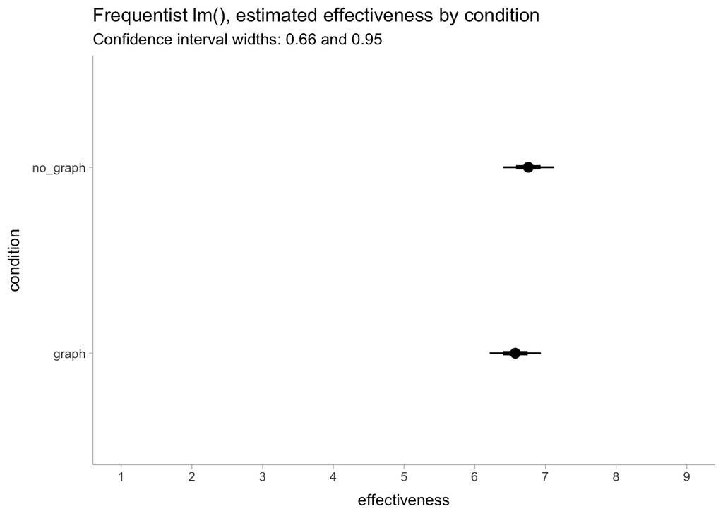

```r
means_t_freq %>%
  ggplot(aes(
    xdist = dist_student_t(
      df = df.residual(m_t_test),
      mu = estimate,
      sigma = std.error),
    y = condition)) +
  # EXERCISE: add 0.66 as another CI level
  stat_pointinterval(.width = c(0.66, 0.95)) +
  scale_x_continuous("effectiveness", breaks = 1:9, limits = c(1, 9)) +
  labs(title = "Frequentist lm(), estimated effectiveness by condition",
       subtitle = "Confidence interval widths: 0.66 and 0.95") +
  NULL
```

**REFLECTION**: how would you plot it if you aren’t using `xdist`/`dist_student_t`?

The **prediction distribution** also follows the t-distribution, so we only need to change the `sigma` parameter. Show that PI is wider than the CI in the plot below!

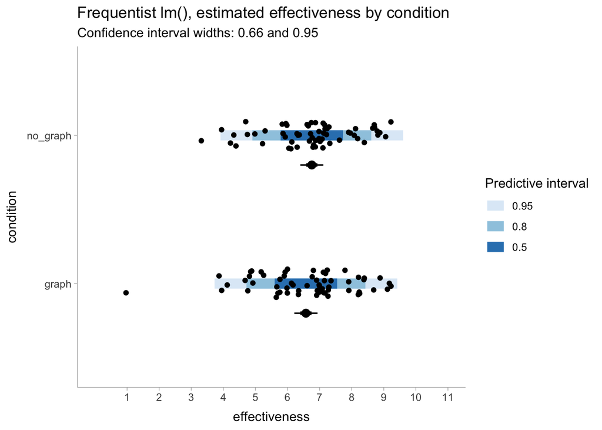

```r
preds_t_freq %>%
  ggplot(aes(y = condition)) +
  # EXERCISE: show PI with stat_interval()
  stat_interval(aes(
    xdist = dist_student_t(
      df = df,
      mu = .fitted,
      sigma = .se.pred)
  )) +

  # PI with dot-and-whisker
  stat_pointinterval(aes(
    xdist = dist_student_t(
      df = df,
      mu = .fitted,
      sigma = .se.fit)),
    position = position_nudge(y = -.2)) +

  # EXERCISE: put raw data in this plot
  geom_point(
    aes(x = effectiveness),
    data = df1, position = jitterer) +

  scale_x_continuous("effectiveness", breaks = 1:11, limits = c(0, 11)) +
  scale_color_brewer("Predictive interval") +
  labs(title = "Frequentist lm(), estimated effectiveness by condition",
       subtitle = "Confidence interval widths: 0.66 and 0.95") +
  NULL
```

Replicate the CI+PI plot above, but with the **Bayesian** model

**REFLECTION**: can we still use `dist_student_t`?

**EXERCISE**: Visualize parameter uncertainty, predictive uncertainty, and the intrinsic uncertainty in data:

```
  (which visual element?) <- (Parameter uncertainty)
  (which visual element?) <- (Predictive uncertainty)
  (which visual element?) <- (Intrinsic uncertainty in data)
```

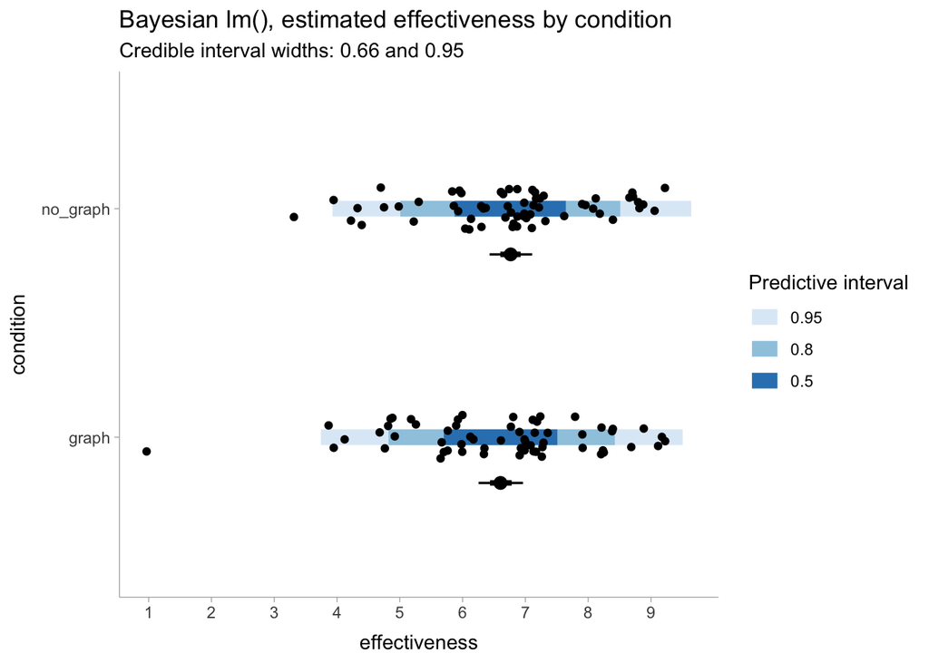

```r
df1 %>%
  ggplot(aes(x = effectiveness, y = condition)) +
  # EXERCISE: fill this out
  stat_interval(
    aes(x = .prediction),
    data = preds_t_bayes) +
  stat_pointinterval(
    aes(x = .epred),
    data = means_t_bayes,
    .width = c(.66, .95),
    position = position_nudge(y = -0.2)) +
  geom_point(position = jitterer) +
  # END EXERCISE
  scale_x_continuous(breaks = 1:9)+
  scale_color_brewer("Predictive interval") +
  labs(title = "Bayesian lm(), estimated effectiveness by condition",
       subtitle = "Credible interval widths: 0.66 and 0.95") +
  NULL
```

### Distributions - parameter and prediction uncertainty

EXERCISE: What encoding do you prefer? How to look for more options?

**Notability**

https://mjskay.github.io/ggdist/

REFLECTION: how would you categorize all these options?

- continuous (`stat_slab`) vs. discrete (`stat_dots`)
- intervals (`stat_interval`) vs. distribution (`stat_slab`) vs. both (`stat_halfeye`)

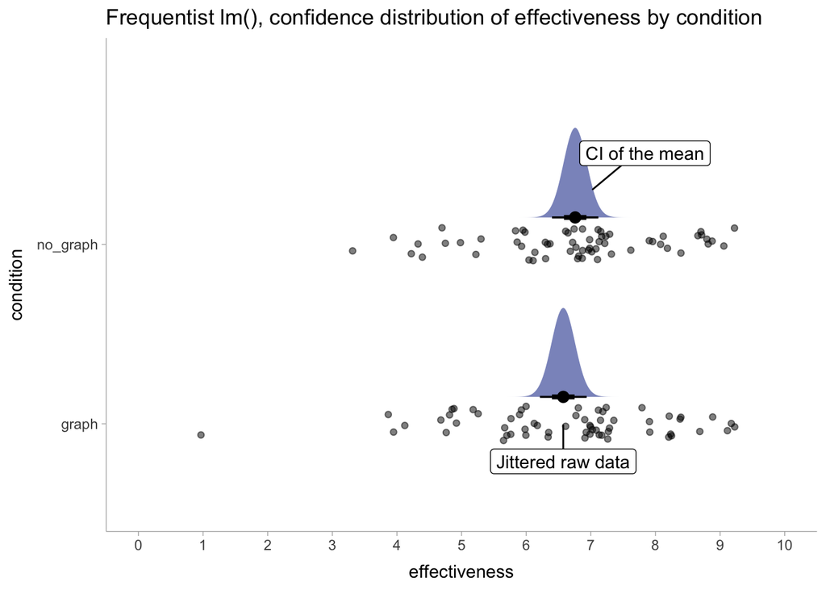

```r
means_t_freq %>%
  ggplot(aes(y = condition)) +
  # EXERCIESE: add raw data
  geom_point(
    aes(
      x = effectiveness,
      y = condition),
    data = df1, position = jitterer, alpha = .5) +

  # EXERCIESE: change to stat_dots
  stat_halfeye(
    aes(xdist =dist_student_t(
      df = df.residual(m_t_test),
      mu = estimate,
      sigma = std.error)),
    scale = 0.5, fill = "#8c96c6",
    position = position_nudge(y = 0.15)) +

  geom_label_repel(
    aes(estimate + 0.25, y = condition),
    data = means_t_freq %>% slice_tail(),
    label = "CI of the mean", box.padding = 1,
    position = position_nudge(y = 0.3), max.overlaps = Inf, seed = 15) +
  # EXERCISE: add a label for the raw data
  geom_label_repel(
    aes(x = estimate, y = condition),
    data = means_t_freq %>% slice_head(),
    label = "Jittered raw data", box.padding = 1,
    position = position_nudge_repel(y = -0.2), seed = 1) +
  scale_x_continuous(breaks = 0:10, limits = c(0, 10)) +
  labs(title = "Frequentist lm(), confidence distribution of effectiveness by condition") +
  NULL
```

Prediction distribution for the frequentist model:

**PREDICTION**: how should it look like? Write a spec below

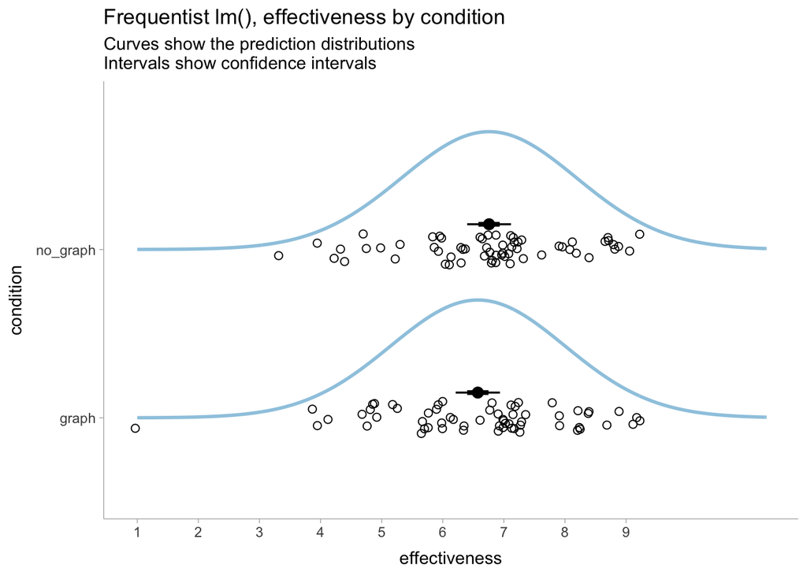

```r
preds_t_freq %>%
  ggplot(aes(y = condition)) +
  stat_slab(
    aes(xdist = dist_student_t(
      df = df,
      mu = .fitted,
      sigma = .se.pred)),
    slab_color="#9ECAE1", fill = NA, scale = 0.7) +
  geom_point(
    aes(
      x = effectiveness,
      y = condition),
    data = df1, position = jitterer, shape = 21, size =2) +
  stat_pointinterval(
    aes(xdist =dist_student_t(
      df = df.residual(m_t_test),
      mu = estimate,
      sigma = std.error)),
    data = means_t_freq,
    scale = 0.5, fill = "#8c96c6",
    position = position_nudge(y = 0.15)) +
  scale_x_continuous(breaks = 1:9) +
  labs(title = "Frequentist lm(), effectiveness by condition",
       subtitle = "Curves show the prediction distributions\nIntervals show confidence intervals") +
  NULL
```

This type of plot is sometimes called Kruschke style in **Bayesian** context https://solomonkurz.netlify.app/post/2018-12-20-make-rotated-gaussians-kruschke-style/. The bunch of density lines shows both parameter and predictive uncertainty (why?)

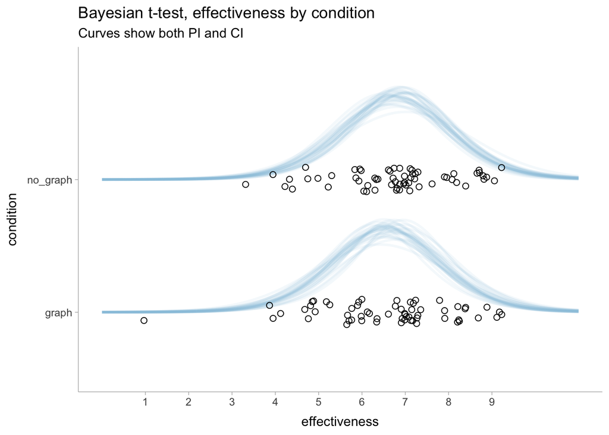

```r
# EXERCISE: adapt the frequentist version for `means_t_bayes`
means_t_bayes %>%
  sample_draws(30) %>%
  ggplot(
    aes(y = condition)) +
  stat_slab(
    aes(xdist = dist_student_t(nu, mu, sigma)),
    slab_color="#9ECAE1", alpha = 0.1, fill = NA, scale = 0.7) +
  # stat_pointinterval(
  #   aes(x = mu),
  #   position = position_nudge(y = 0.15)) +
  geom_point(
    aes(x = effectiveness), data = df1,
    shape = 21, size = 2,
    position = jitterer) +
  scale_x_continuous(breaks = 1:9, limit = c(0, 11)) +
  labs(title = "Bayesian t-test, effectiveness by condition",
       subtitle = "Curves show both PI and CI") +
  NULL
```

**REFLECTION**: why does the Kruschke spaghetti density show both PI and CI? How else can you show PI for the Bayesian model? Hints:

- Many prediction distribution implied by the posterior
- Single posterior predictive distribution integrated over parameter uncertainty

**REFLECTION**: should you show confidence or prediction distribution, or both? Should you use intervals or distributions for uncertainty? …*usability*

*BREAK TIME*

## Activity 3: Ordinal logistic regression

*Paired programming!*

Now you will design your own plots for the frequentist and Bayesian ordinal linear regression. You have data exploration and model output summaries below.

### Considerations and resources

- What does the model look like? How does it work?
- What are the parameter and prediction uncertainty?
- How do I want to visualize the uncertainties? (Interval? distribution?)
- (Bayesian) OLR https://bookdown.org/ajkurz/Statistical_Rethinking_recoded/monsters-and-mixtures.html#ordered-categorical-outcomes

*To the break out rooms!*

### Data exploration and how cumulative logit works

The same `df1` data, but summarized to show proportion of each effectiveness level (1-9).

```r
(df1_prop <- df1 %>%
  count(condition, effectiveness) %>%
  add_row(condition = "graph", effectiveness = 2, n = 0) %>%
  complete(condition, effectiveness, fill = list(n = 0)) %>%
  group_by(condition) %>%
  mutate(prob = n/sum(n))
)
```

```
## # A tibble: 18 × 4
## # Groups:   condition [2]
##    condition effectiveness     n   prob
##    <chr>             <dbl> <dbl>  <dbl>
##  1 graph                 1     1 0.0164
##  2 graph                 2     0 0
##  3 graph                 3     0 0
##  4 graph                 4     3 0.0492
##  5 graph                 5     8 0.131
##  6 graph                 6    14 0.230
##  7 graph                 7    21 0.344
##  8 graph                 8     9 0.148
##  9 graph                 9     5 0.0820
## 10 no_graph              1     0 0
## 11 no_graph              2     0 0
## 12 no_graph              3     1 0.0161
## 13 no_graph              4     4 0.0645
## 14 no_graph              5     5 0.0806
## 15 no_graph              6    12 0.194
## 16 no_graph              7    25 0.403
## 17 no_graph              8     7 0.113
## 18 no_graph              9     8 0.129
```

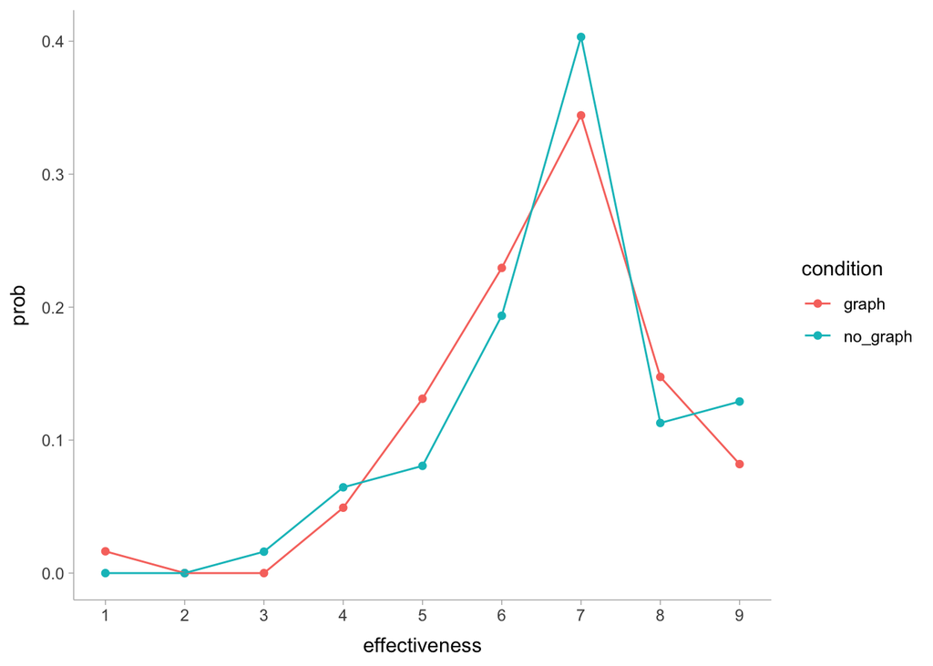

```r
df1_prop %>%
  ggplot(aes(x = effectiveness, y = prob, color = condition)) +
  geom_point() +
  geom_line() +
  scale_x_continuous(breaks = 1:9) +
  NULL
```

Building up to the ordinal linear regression model… introducing the cumulative proportions (“odds”), and cumulative log odds (computed with `logit()`)

```r
logit <- function(x) log(x / (1 - x))

(cumu_df1 <- df1 %>%
  count(condition, effectiveness, name = "n") %>%
  add_row(condition = "graph", effectiveness = 2, n = 0) %>%
  complete(condition, effectiveness, fill = list(n = 0)) %>%
  group_by(condition) %>%
  mutate(
    pr_k = n / sum(n),
    cum_pr_k = cumsum(pr_k),
    cum_pr_k_1 = cum_pr_k - (pr_k),
    logit_cum_pr_k = logit(cum_pr_k))
)
```

```
## # A tibble: 18 × 7
## # Groups:   condition [2]
##    condition effectiveness     n   pr_k cum_pr_k cum_pr_k_1 logit_cum_pr_k
##    <chr>             <dbl> <dbl>  <dbl>    <dbl>      <dbl>          <dbl>
##  1 graph                 1     1 0.0164   0.0164     0              -4.09
##  2 graph                 2     0 0        0.0164     0.0164         -4.09
##  3 graph                 3     0 0        0.0164     0.0164         -4.09
##  4 graph                 4     3 0.0492   0.0656     0.0164         -2.66
##  5 graph                 5     8 0.131    0.197      0.0656         -1.41
##  6 graph                 6    14 0.230    0.426      0.197          -0.297
##  7 graph                 7    21 0.344    0.770      0.426           1.21
##  8 graph                 8     9 0.148    0.918      0.770           2.42
##  9 graph                 9     5 0.0820   1          0.918         Inf
## 10 no_graph              1     0 0        0          0            -Inf
## 11 no_graph              2     0 0        0          0            -Inf
## 12 no_graph              3     1 0.0161   0.0161     0              -4.11
## 13 no_graph              4     4 0.0645   0.0806     0.0161         -2.43
## 14 no_graph              5     5 0.0806   0.161      0.0806         -1.65
## 15 no_graph              6    12 0.194    0.355      0.161          -0.598
## 16 no_graph              7    25 0.403    0.758      0.355           1.14
## 17 no_graph              8     7 0.113    0.871      0.758           1.91
## 18 no_graph              9     8 0.129    1          0.871         Inf
```

The first figure, but on log cumulative odds scale. Can you interpret the labeled numbers?

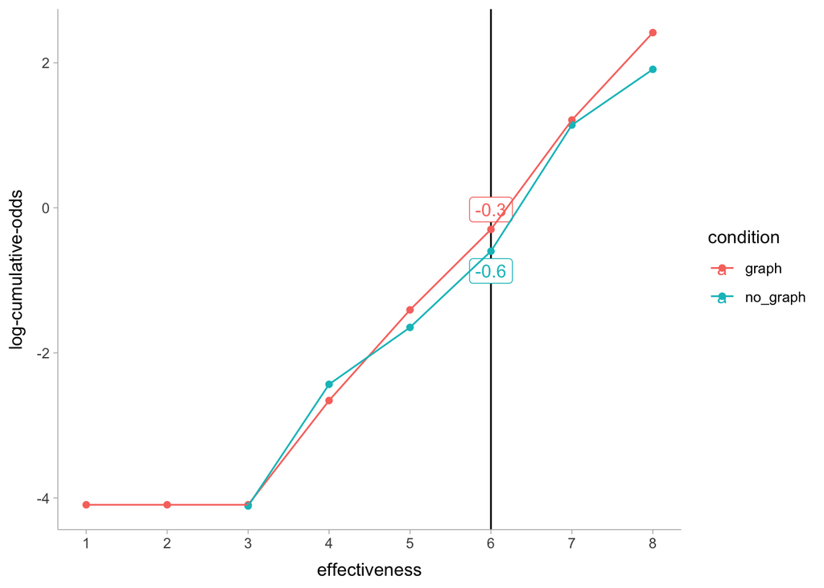

```r
cumu_df1 %>%
  filter(!is.infinite(logit_cum_pr_k)) %>%
  ggplot(aes(x = effectiveness, y = logit_cum_pr_k, color = condition, label = round(logit_cum_pr_k, 2))) +
  geom_vline(xintercept = 6) +
  geom_label_repel(data = cumu_df1 %>% filter(effectiveness == 6)) +
  geom_point() +
  geom_line() +
  scale_x_continuous(breaks = 1:9) +
  ylab("log-cumulative-odds")
```

Once we have the estimates in the cumulative log odds space, can do inverse logit (`brms::inv_logit_scaled()`), and get proportions out of the cumulative proportions. The vertical straight lines are the individual proportions at each effectiveness level.

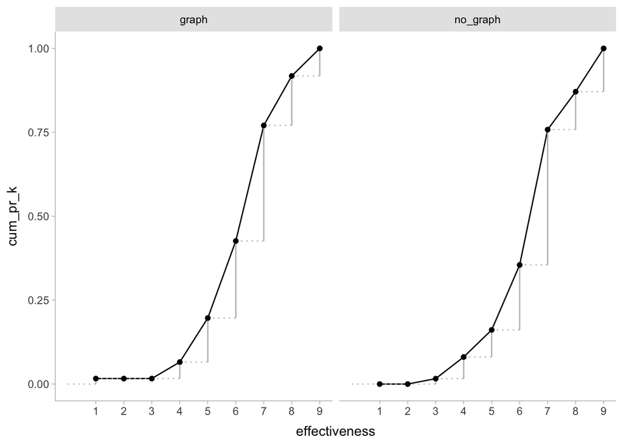

```r
cumu_df1 %>%
  ggplot(aes(x = effectiveness, y = cum_pr_k)) +
  geom_line() +
  geom_segment(aes(
    x = effectiveness,
    xend = effectiveness,
    y = cum_pr_k,
    yend = cum_pr_k_1),
    color = "grey") +
  geom_segment(aes(
    x = effectiveness - 1,
    xend = effectiveness,
    y = cum_pr_k_1,
    yend = cum_pr_k_1),
    linetype = "dotted", color = "grey") +
  geom_point() +
  scale_x_continuous(breaks = 1:9) +
  facet_grid(~condition)
```

### Frequentist model

Frequentist

```r
(m_polr <- df1 %>%
  mutate(effectiveness = ordered(effectiveness, levels = as.character(1:9))) %>%
  MASS::polr(effectiveness ~ condition, data = ., Hess=TRUE)
)
```

```
## Call:
## MASS::polr(formula = effectiveness ~ condition, data = ., Hess = TRUE)
##
## Coefficients:
## conditionno_graph
##          0.219634
##
## Intercepts:
##        1|2        2|3        3|4        4|5        5|6        6|7        7|8
## -4.6983544 -4.6980124 -3.9967452 -2.4346636 -1.4188262 -0.3367293  1.2893831
##        8|9
##  2.2496567
##
## Residual Deviance: 412.3386
## AIC: 430.3386
```

Estimates of the intercepts on the logit scale

```r
tidy(m_polr)
```

```
## # A tibble: 9 × 5
##   term              estimate std.error statistic coef.type
##   <chr>                <dbl>     <dbl>     <dbl> <chr>
## 1 conditionno_graph    0.220     0.324     0.678 coefficient
## 2 1|2                 -4.70      1.01     -4.63  scale
## 3 2|3                 -4.70      1.01     -4.63  scale
## 4 3|4                 -4.00      0.729    -5.49  scale
## 5 4|5                 -2.43      0.378    -6.45  scale
## 6 5|6                 -1.42      0.281    -5.06  scale
## 7 6|7                 -0.337     0.245    -1.38  scale
## 8 7|8                  1.29      0.271     4.75  scale
## 9 8|9                  2.25      0.339     6.63  scale
```

Estimates on the probability scale

```r
(means_olr_freq <- emmeans(m_polr,  ~ condition + effectiveness, mode = "prob") %>%
  as.data.frame()
)
```

```
##    condition effectiveness         prob           SE  df     asymp.LCL
## 1      graph             1 9.028009e-03 0.0090731953 Inf -0.0087551269
## 2   no_graph             1 7.260725e-03 0.0073320127 Inf -0.0071097561
## 3      graph             2 3.060120e-06 0.0001656644 Inf -0.0003216361
## 4   no_graph             2 2.465474e-06 0.0001334725 Inf -0.0002591358
## 5      graph             3 9.012720e-03 0.0090536707 Inf -0.0087321485
## 6   no_graph             3 7.274315e-03 0.0073418674 Inf -0.0071154808
## 7      graph             4 6.252354e-02 0.0243310709 Inf  0.0148355148
## 8   no_graph             4 5.118711e-02 0.0205935258 Inf  0.0108245457
## 9      graph             5 1.142783e-01 0.0323333457 Inf  0.0509061484
## 10  no_graph             5 9.695007e-02 0.0286442454 Inf  0.0408083837
## 11     graph             6 2.217585e-01 0.0409952428 Inf  0.1414093150
## 12  no_graph             6 2.017146e-01 0.0384554632 Inf  0.1263433139
## 13     graph             7 3.674386e-01 0.0446247852 Inf  0.2799755915
## 14  no_graph             7 3.801599e-01 0.0447786893 Inf  0.2923952377
```

[output cut: 23 more lines]

EXERCISE: plot estimates on the cumulative log odds scale. One option:

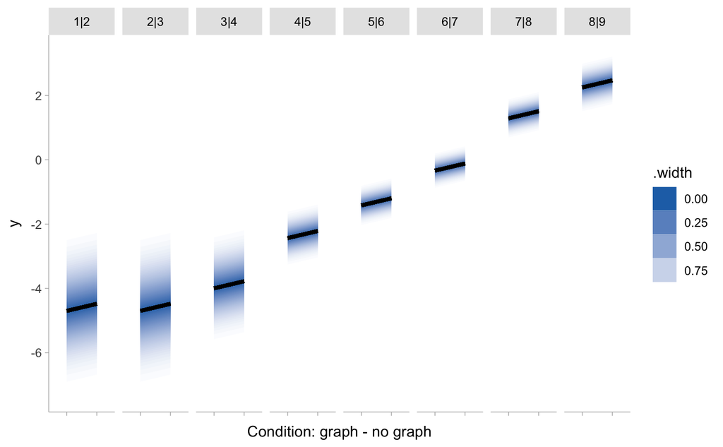

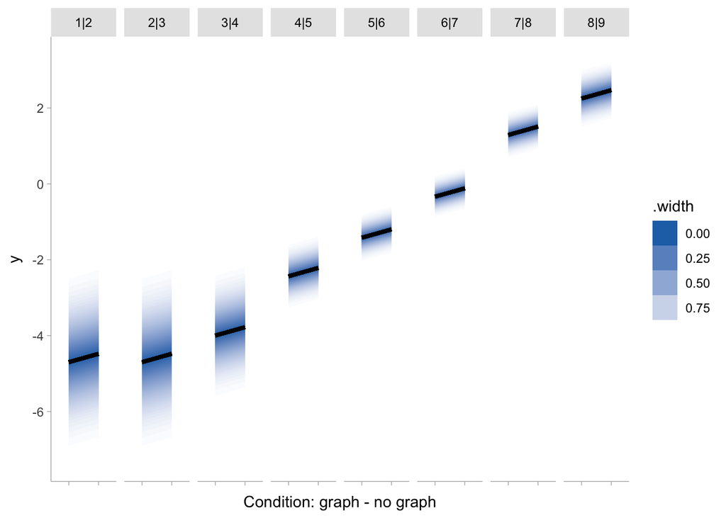

```r
tidy(m_polr) %>%
 mutate(delta = first(estimate)) %>%
  dplyr::slice(-1) %>%
  crossing(condition = data_grid(df1, condition) %>% pull(condition))  %>%
  mutate(estimate = ifelse(condition == "no_graph", estimate + delta, estimate)) %>%
  select(-delta) %>%
  ggplot() +
  stat_lineribbon(aes(
    x = condition,
    ydist = dist_normal(
      mu = estimate,
      sigma = std.error),
    fill_ramp = stat(.width)), .width = ppoints(50), fill = "#2171b5"
  ) +
  facet_grid(~ term) + # EXERCISE: uncomment to see data better
  scale_fill_ramp_continuous(range = c(1, 0)) +
  theme(axis.text.x = element_blank()) +
  xlab("Condition: graph - no graph") +
  NULL
```

EXERCISE: On the probability scale. One design:

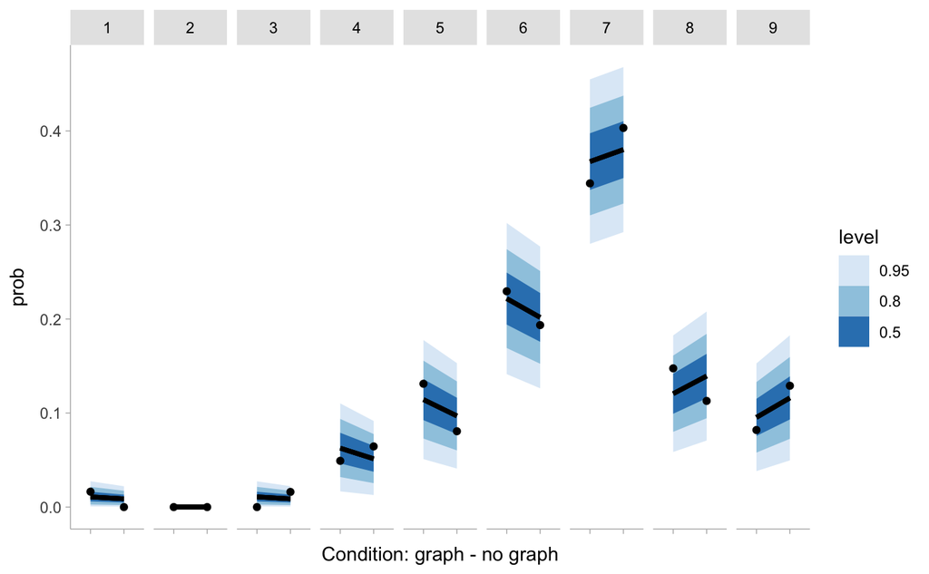

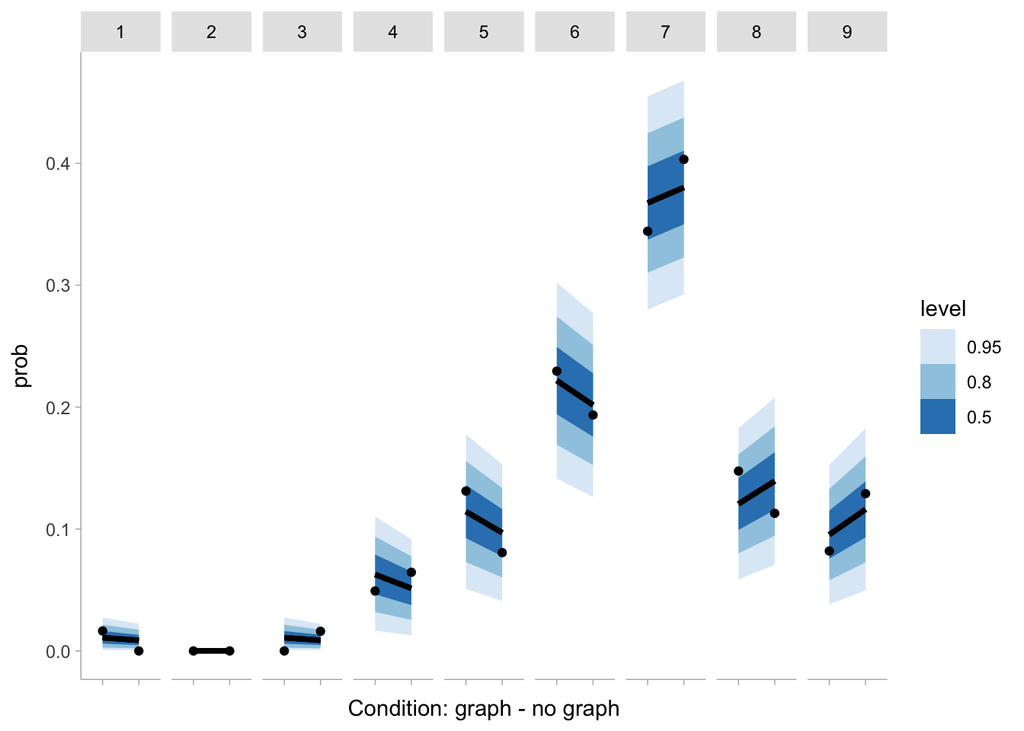

```r
means_olr_freq %>%
  ggplot(aes(x = condition, y = prob, group = effectiveness)) +
  stat_lineribbon(aes(
    ydist = dist_truncated(dist_normal(mu = prob, sigma = SE), lower = 0)
  )) +
  geom_point(data = df1_prop) +
  facet_grid(~ effectiveness) + # EXERCISE: uncomment to see data better
  theme(axis.text.x = element_blank()) +
  scale_fill_brewer() +
  xlab("Condition: graph - no graph") +
  NULL
```

### Bayesian OLR

Load the data

```r
(m_olr_bayes <- readRDS("../02-bayesian_stats/rds/dataset1.brm.olr1.rds"))
```

```
##  Family: cumulative
##   Links: mu = logit; disc = identity
## Formula: effectiveness ~ condition
##    Data: exp1.data (Number of observations: 123)
##   Draws: 4 chains, each with iter = 2000; warmup = 1000; thin = 1;
##          total post-warmup draws = 4000
##
## Population-Level Effects:
##                   Estimate Est.Error l-95% CI u-95% CI Rhat Bulk_ESS Tail_ESS
## Intercept[1]         -4.79      0.94    -6.96    -3.23 1.00     1762     1141
## Intercept[2]         -4.20      0.78    -5.98    -2.93 1.00     2466     1865
## Intercept[3]         -3.46      0.57    -4.71    -2.47 1.00     3340     2834
## Intercept[4]         -2.24      0.34    -2.97    -1.60 1.00     4238     3087
## Intercept[5]         -1.32      0.26    -1.83    -0.81 1.00     4691     3695
## Intercept[6]         -0.30      0.23    -0.74     0.17 1.00     4264     3276
## Intercept[7]          1.28      0.27     0.77     1.81 1.00     3594     3170
## Intercept[8]          2.26      0.34     1.63     2.96 1.00     3702     2956
## conditionno_graph     0.19      0.30    -0.38     0.78 1.00     4122     2809
##
## Family Specific Parameters:
##      Estimate Est.Error l-95% CI u-95% CI Rhat Bulk_ESS Tail_ESS
## disc     1.00      0.00     1.00     1.00   NA       NA       NA
##
## Draws were sampled using sampling(NUTS). For each parameter, Bulk_ESS
## and Tail_ESS are effective sample size measures, and Rhat is the potential
## scale reduction factor on split chains (at convergence, Rhat = 1).
```

Get posterior estimates for the parameters and predictions (outcome on the scale of 1…9)

```r
(means_olr_bayes <- expand(df1, condition) %>%
  add_epred_draws(m_olr_bayes, dpar = TRUE) %>%
   rename(effectiveness = .category)
)
```

```
## # A tibble: 72,000 × 9
## # Groups:   condition, .row, effectiveness [18]
##    condition  .row .chain .iteration .draw effectiveness  .epred    mu  disc
##    <fct>     <int>  <int>      <int> <int> <fct>           <dbl> <dbl> <dbl>
##  1 graph         1     NA         NA     1 1             0.0124    0.5     1
##  2 graph         1     NA         NA     2 1             0.0116    0.5     1
##  3 graph         1     NA         NA     3 1             0.0185    0.5     1
##  4 graph         1     NA         NA     4 1             0.0335    0.5     1
##  5 graph         1     NA         NA     5 1             0.0219    0.5     1
##  6 graph         1     NA         NA     6 1             0.00192   0.5     1
##  7 graph         1     NA         NA     7 1             0.0145    0.5     1
##  8 graph         1     NA         NA     8 1             0.00389   0.5     1
##  9 graph         1     NA         NA     9 1             0.0137    0.5     1
## 10 graph         1     NA         NA    10 1             0.00495   0.5     1
## # … with 71,990 more rows
```

```r
(preds_olr_bayes <- df1 %>%
    add_predicted_draws(m_olr_bayes) %>%
    select(-c(.chain, .iteration)) %>%
   drop_na()
 )
```

```
## # A tibble: 439,649 × 6
## # Groups:   condition, effectiveness, participant_id, .row [123]
##    condition effectiveness participant_id  .row .draw .prediction
##    <fct>             <dbl> <chr>          <int> <int> <fct>
##  1 no_graph              7 P01                1     1 8
##  2 no_graph              7 P01                1     2 9
##  3 no_graph              7 P01                1     3 9
##  4 no_graph              7 P01                1     4 9
##  5 no_graph              7 P01                1     5 8
##  6 no_graph              7 P01                1     6 8
##  7 no_graph              7 P01                1     7 8
##  8 no_graph              7 P01                1     8 8
##  9 no_graph              7 P01                1     9 6
## 10 no_graph              7 P01                1    10 6
## # … with 439,639 more rows
```

EXERCISE: make a plot for those mean estimates! One design:

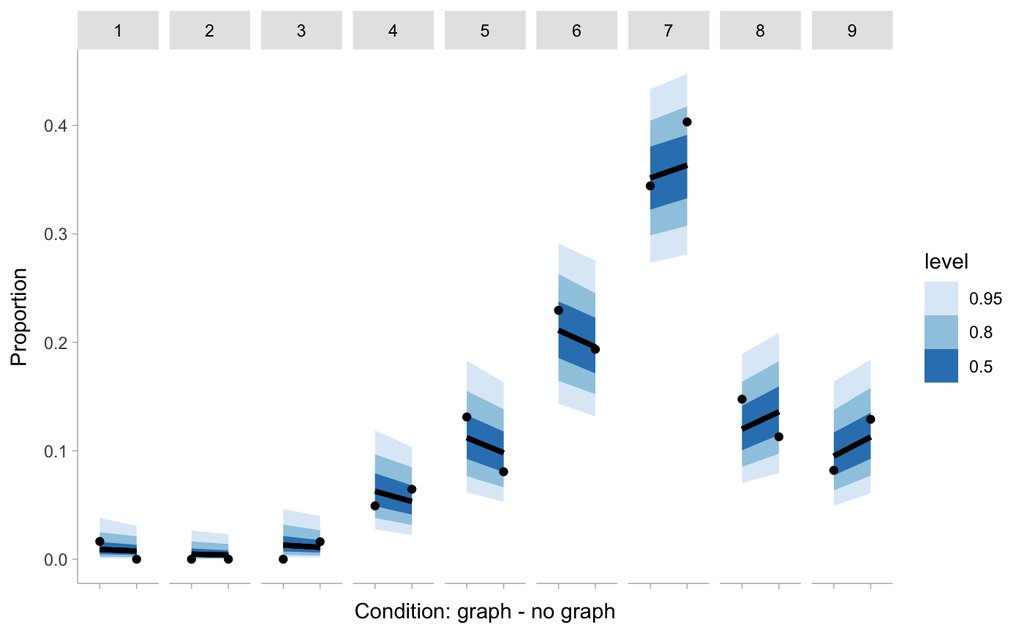

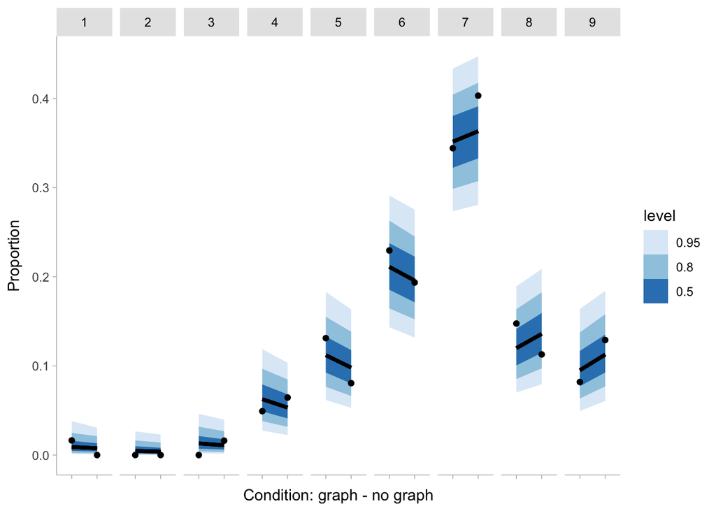

```r
means_olr_bayes %>%
  ggplot(aes(x = condition, y = .epred)) +
  stat_lineribbon()  +
  geom_point(aes(x = condition, y = prob), data = df1_prop) +
  scale_fill_brewer() +
  facet_grid(~ effectiveness) +
  theme(axis.text.x = element_blank()) +
  xlab("Condition: graph - no graph") +
  ylab("Proportion")
```

```r
(means_df1_olr_compare <- means_olr_bayes %>%
  group_by(effectiveness) %>%
  compare_levels(variable = .epred, by = condition )
)
```

```
## # A tibble: 36,000 × 6
## # Groups:   effectiveness, condition [9]
##    effectiveness .chain .iteration .draw condition            .epred
##    <fct>          <int>      <int> <int> <chr>                 <dbl>
##  1 1                 NA         NA     1 no_graph - graph  0.00340
##  2 1                 NA         NA     2 no_graph - graph -0.00469
##  3 1                 NA         NA     3 no_graph - graph -0.00505
##  4 1                 NA         NA     4 no_graph - graph -0.00109
##  5 1                 NA         NA     5 no_graph - graph -0.00582
##  6 1                 NA         NA     6 no_graph - graph  0.0000320
##  7 1                 NA         NA     7 no_graph - graph -0.00412
##  8 1                 NA         NA     8 no_graph - graph -0.00110
##  9 1                 NA         NA     9 no_graph - graph -0.00410
## 10 1                 NA         NA    10 no_graph - graph -0.00106
## # … with 35,990 more rows
```

```r
(df1_prop_diff <- df1_prop %>%
  pivot_wider(id_col = effectiveness, names_from = condition, values_from = prob) %>%
  drop_na() %>%
  mutate(diff = no_graph - graph)
)
```

```
## # A tibble: 9 × 4
##   effectiveness  graph no_graph    diff
##           <dbl>  <dbl>    <dbl>   <dbl>
## 1             1 0.0164   0      -0.0164
## 2             2 0        0       0
## 3             3 0        0.0161  0.0161
## 4             4 0.0492   0.0645  0.0153
## 5             5 0.131    0.0806 -0.0505
## 6             6 0.230    0.194  -0.0360
## 7             7 0.344    0.403   0.0590
## 8             8 0.148    0.113  -0.0346
## 9             9 0.0820   0.129   0.0471
```

EXERCISE: compare the two conditions

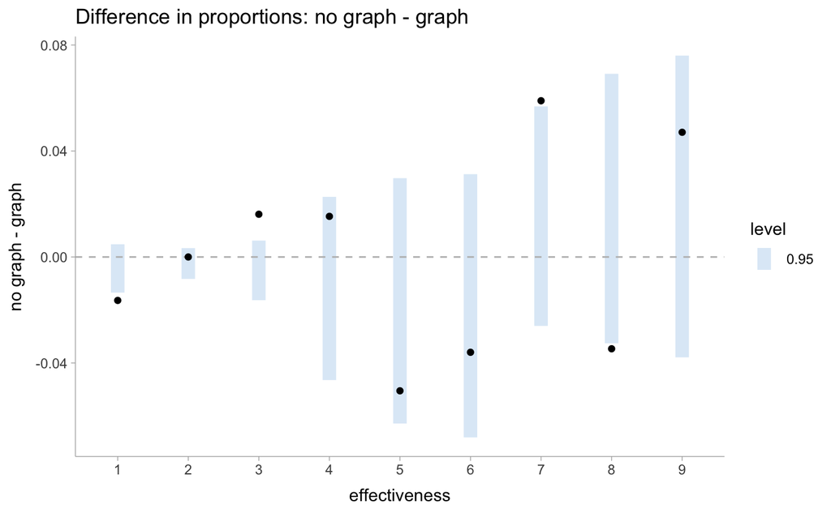

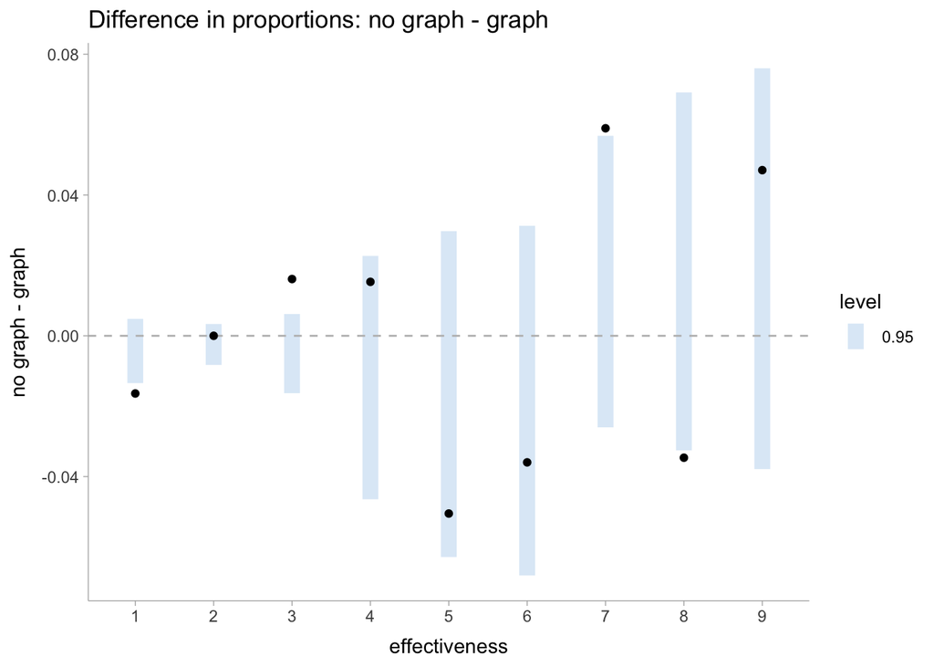

```r
means_df1_olr_compare %>%
  ggplot(aes(x = effectiveness, y = .epred)) +
  stat_interval(.width = c(0.95)) +  # EXERCISE: can you be more expressive with uncertainty?
  geom_hline(                        # EXERCISE: add reference line y = 0
    yintercept = 0, linetype = "dashed", color = "grey") +
  geom_point(aes(y = diff), data= df1_prop_diff) +  #EXERCISE: add raw data
  scale_color_brewer() +
  ylab("no graph - graph") +
  labs(title = "Difference in proportions: no graph - graph") +
  NULL
```

RELFECTION: how else to show the prediction uncertainty?

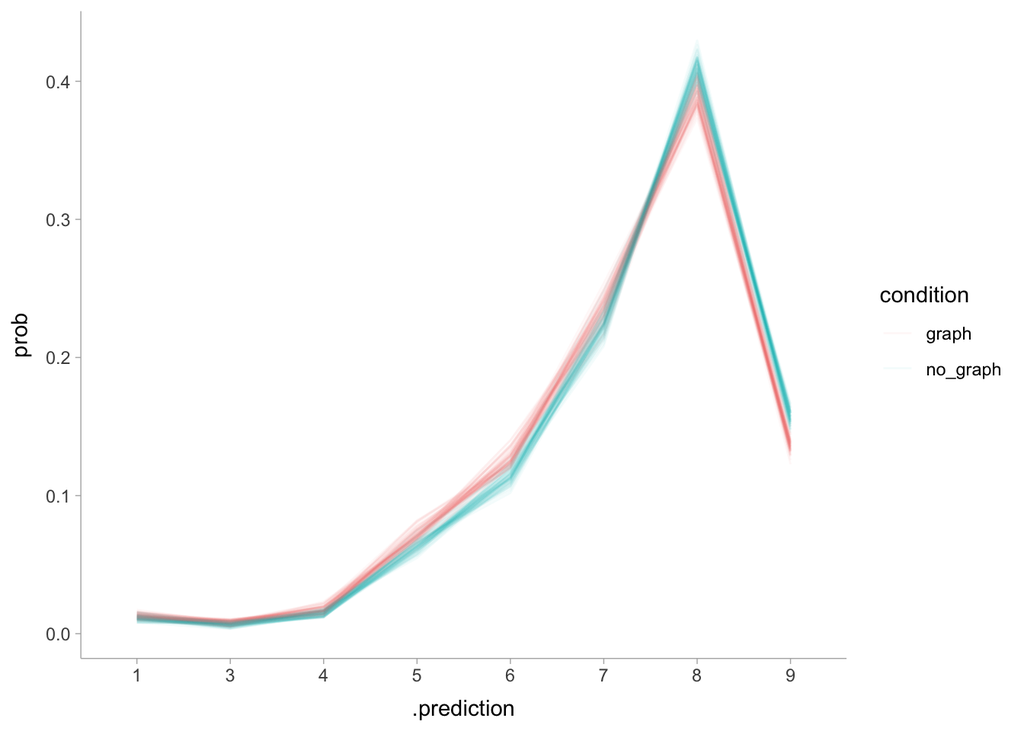

```r
preds_olr_bayes %>%
  count(.row, condition, .prediction) %>%
  mutate(prob = n / sum(n)) %>%
  ggplot(aes(.prediction, prob, group = .row, color = condition)) +
  geom_line(alpha = 0.05) +
  NULL
```